# DermaMNIST Mini Research Prototype: Full Workflow

**Question:** On a small, heavily imbalanced skin-lesion dataset, which CPU-friendly classifiers give the best *macro-F1* (not accuracy), and how well calibrated are they?

Workflow: environment → data → EDA → preprocessing → training (5 models) → evaluation & calibration → MLflow → FastAPI → conclusions.

> Research/education prototype. **Not a diagnostic device.**

## 1. Environment setup

Create the env once from the repo root:

```
python -m venv .venv
.venv\Scripts\activate        # Windows; Linux/macOS: source .venv/bin/activate
pip install -r requirements.txt
```

```python
import os, sys, warnings
if os.path.basename(os.getcwd()) == 'notebooks':
    os.chdir('..')
sys.path.insert(0, os.getcwd())
os.environ['MLFLOW_DISABLE_AGENT_HINT'] = '1'
warnings.filterwarnings('ignore')
import numpy as np, pandas as pd, matplotlib.pyplot as plt, sklearn, mlflow
from src.data import load_config, load_splits, to_features, CLASSES
cfg = load_config()
print('python', sys.version.split()[0], '| sklearn', sklearn.__version__, '| mlflow', mlflow.__version__)
cfg
```

```
python 3.14.6 | sklearn 1.9.1 | mlflow 3.17.0
```

```
{'seed': 42,
 'data_url': 'https://zenodo.org/records/10519652/files/dermamnist.npz',
 'data_path': 'data/dermamnist.npz',
 'mlflow_uri': 'sqlite:///mlflow.db',
 'experiment': 'dermamnist-baselines',
 'registered_model': 'dermamnist-classifier',
 'out_dir': 'results'}
```

## 2. Data loading

DermaMNIST (MedMNIST v2) is HAM10000 dermatoscopic images resized to 28×28 RGB, 7 classes, with the official train/val/test split. It is downloaded from Zenodo on first use.

```python
splits = load_splits(cfg)
for s, (Xs, ys) in splits.items():
    print(f'{s:5s} images={Xs.shape} labels={ys.shape} dtype={Xs.dtype}')
```

```
train images=(7007, 28, 28, 3) labels=(7007,) dtype=uint8
val   images=(1003, 28, 28, 3) labels=(1003,) dtype=uint8
test  images=(2005, 28, 28, 3) labels=(2005,) dtype=uint8
```

## 3. Exploratory data analysis

```python
counts = pd.DataFrame({s: pd.Series(ys).value_counts().sort_index() for s, (_, ys) in splits.items()})
counts.index = CLASSES
counts['train_%'] = (100 * counts['train'] / counts['train'].sum()).round(1)
counts
```

|  | train | val | test | train_% |
| --- | --- | --- | --- | --- |
| actinic keratoses | 228 | 33 | 66 | 3.3 |
| basal cell carcinoma | 359 | 52 | 103 | 5.1 |
| benign keratosis-like lesions | 769 | 110 | 220 | 11.0 |
| dermatofibroma | 80 | 12 | 23 | 1.1 |
| melanoma | 779 | 111 | 223 | 11.1 |
| melanocytic nevi | 4693 | 671 | 1341 | 67.0 |
| vascular lesions | 99 | 14 | 29 | 1.4 |

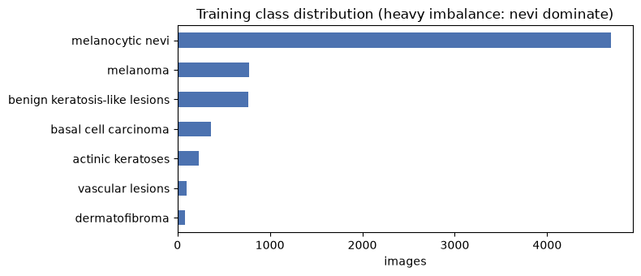

```python
fig, ax = plt.subplots(figsize=(8, 3.5))
counts['train'].sort_values().plot.barh(ax=ax, color='#4C72B0')
ax.set_title('Training class distribution (heavy imbalance: nevi dominate)'); ax.set_xlabel('images')
plt.tight_layout(); plt.show()
```

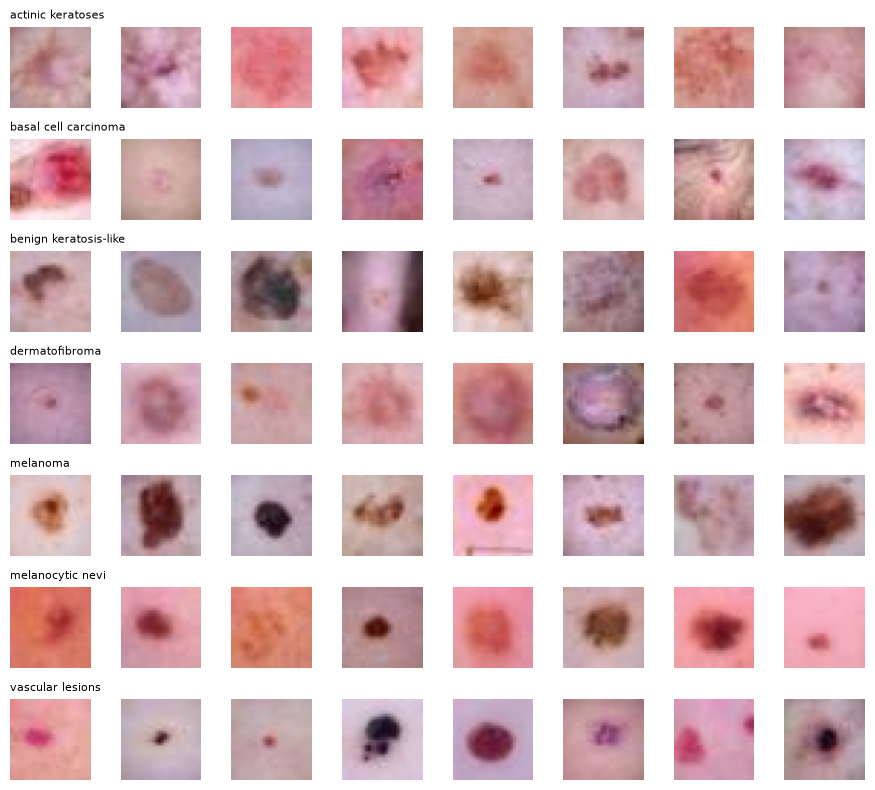

```python
Xtr, ytr = splits['train']
fig, axes = plt.subplots(7, 8, figsize=(9, 8))
for c in range(7):
    for j, i in enumerate(np.where(ytr == c)[0][:8]):
        axes[c, j].imshow(Xtr[i])
    for a in axes[c]:
        a.axis('off')
    axes[c, 0].set_title(CLASSES[c][:22], fontsize=8, loc='left')
plt.tight_layout(); plt.show()
```

```python
# Per-class mean colour: a cheap signal the colour-histogram features exploit
means = pd.DataFrame([Xtr[ytr == c].reshape(-1, 3).mean(0) for c in range(7)], index=CLASSES, columns=['R', 'G', 'B']).round(1)
print('pixel range:', Xtr.min(), Xtr.max(), '| no missing values in uint8 arrays')
means
```

```
pixel range: 0 255 | no missing values in uint8 arrays
```

|  | R | G | B |
| --- | --- | --- | --- |
| actinic keratoses | 200.3 | 149.7 | 155.9 |
| basal cell carcinoma | 198.0 | 156.6 | 163.6 |
| benign keratosis-like lesions | 180.4 | 140.0 | 147.2 |
| dermatofibroma | 199.4 | 148.7 | 157.7 |
| melanoma | 178.3 | 136.5 | 142.8 |
| melanocytic nevi | 198.9 | 134.4 | 139.7 |
| vascular lesions | 197.8 | 146.2 | 161.6 |

## 4. Preprocessing

Features are 2,352 scaled pixels plus 48 colour-histogram bins. Model pipelines then add StandardScaler + PCA(100) where useful. Imbalance is handled with `class_weight='balanced'`. The splits are the official ones, and model selection uses **validation** only.

```python
X = {s: to_features(x) for s, (x, _) in splits.items()}
y = {s: lab for s, (_, lab) in splits.items()}
{s: v.shape for s, v in X.items()}
```

```
{'train': (7007, 2400), 'val': (1003, 2400), 'test': (2005, 2400)}
```

## 5. Model training + MLflow tracking

`src/train.py` trains 5 models (dummy prior, logistic regression, random forest, HistGradientBoosting, MLP). For each it logs params, val/test metrics, the confusion matrix and the model to MLflow. It then registers the best model, chosen on validation macro-F1, in the MLflow Model Registry.

```python
from src import train
train.main()
```

```
2026/10/08 00:11:48 INFO mlflow.store.db.utils: Creating initial MLflow database tables...
```

```
2026/10/08 00:11:48 INFO mlflow.store.db.utils: Updating database tables
```

```
2026/10/08 00:11:50 INFO mlflow.tracking.fluent: Experiment with name 'dermamnist-baselines' does not exist. Creating a new experiment.
```

```
dummy_prior    val_macroF1=0.115 test_macroF1=0.115 (0s)
```

```
logreg         val_macroF1=0.343 test_macroF1=0.363 (3s)
```

```
random_forest  val_macroF1=0.248 test_macroF1=0.259 (11s)
```

```
hist_gb        val_macroF1=0.406 test_macroF1=0.419 (14s)
```

```
mlp            val_macroF1=0.475 test_macroF1=0.427 (4s)
```

```
Successfully registered model 'dermamnist-classifier'.
2026/10/08 00:13:05 WARNING mlflow.tracking._model_registry.fluent: Run with id d1ba34fa612641bb8c470177d84fe157 has no artifacts at artifact path 'model', registering model based on models:/m-18422dbdff79422782e846e38e07b2bd instead
```

```
McNemar mlp vs hist_gb: p=0.0000
        model                           run_id  fit_seconds  val_macro_f1  val_balanced_acc  val_accuracy  val_roc_auc_ovr  val_ece  test_macro_f1  test_balanced_acc  test_accuracy  test_roc_auc_ovr  test_ece  temperature  test_ece_temp_scaled  test_macro_f1_ci_low  test_macro_f1_ci_high
          mlp d1ba34fa612641bb8c470177d84fe157          4.5        0.4747            0.4413        0.7428           0.8989   0.0985         0.4273             0.3941         0.7272            0.8976    0.1244       1.8006                0.0234                0.3742                 0.4701
      hist_gb e4cc2f3dd0104017b81f61592d196ad6         14.2        0.4061            0.4169        0.6570           0.8623   0.0501         0.4190             0.4313         0.6648            0.8707    0.0423       0.8529                0.0362                0.3791                 0.4570
       logreg 74289add1f7c42c8bc71034b19b75ba8          3.4        0.3427            0.4571        0.5304           0.8443   0.1071         0.3629             0.4929         0.5451            0.8459    0.0933       1.4598                0.0280                0.3347                 0.3916
random_forest 394e948a22ca4e6aaeab6c2fa2d294f4         10.5        0.2480            0.2322        0.6919           0.8944   0.0701         0.2592             0.2408         0.7097            0.8973    0.0350       0.8470                0.0374                0.2346                 0.2826
  dummy_prior 8700ce36596d4274b4927a32fd81f89e          0.0        0.1145            0.1429        0.6690           0.5000   0.0008         0.1145             0.1429         0.6688            0.5000    0.0009       1.0026                0.0003                0.1124                 0.1167
Best (val macro-F1): mlp -> registered v1
```

```
Created version '1' of model 'dermamnist-classifier'.
```

## 6. Evaluation and comparison

```python
res = pd.read_csv('results/model_comparison.csv')
print(open('results/significance.json').read())
res[['model', 'val_macro_f1', 'test_macro_f1', 'test_macro_f1_ci_low', 'test_macro_f1_ci_high', 'test_balanced_acc', 'test_accuracy', 'test_roc_auc_ovr', 'test_ece', 'test_ece_temp_scaled', 'temperature']]
```

```
{
  "model_a": "mlp",
  "model_b": "hist_gb",
  "mcnemar_exact_p": 0.0
}
```

|  | model | val_macro_f1 | test_macro_f1 | test_macro_f1_ci_low | test_macro_f1_ci_high | test_balanced_acc | test_accuracy | test_roc_auc_ovr | test_ece | test_ece_temp_scaled | temperature |
| --- | --- | --- | --- | --- | --- | --- | --- | --- | --- | --- | --- |
| 0 | mlp | 0.4747 | 0.4273 | 0.3742 | 0.4701 | 0.3941 | 0.7272 | 0.8976 | 0.1244 | 0.0234 | 1.8006 |
| 1 | hist_gb | 0.4061 | 0.4190 | 0.3791 | 0.4570 | 0.4313 | 0.6648 | 0.8707 | 0.0423 | 0.0362 | 0.8529 |
| 2 | logreg | 0.3427 | 0.3629 | 0.3347 | 0.3916 | 0.4929 | 0.5451 | 0.8459 | 0.0933 | 0.0280 | 1.4598 |
| 3 | random_forest | 0.2480 | 0.2592 | 0.2346 | 0.2826 | 0.2408 | 0.7097 | 0.8973 | 0.0350 | 0.0374 | 0.8470 |
| 4 | dummy_prior | 0.1145 | 0.1145 | 0.1124 | 0.1167 | 0.1429 | 0.6688 | 0.5000 | 0.0009 | 0.0003 | 1.0026 |

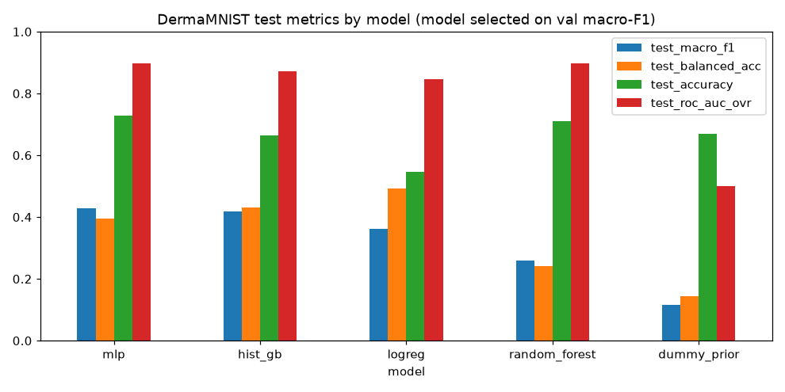

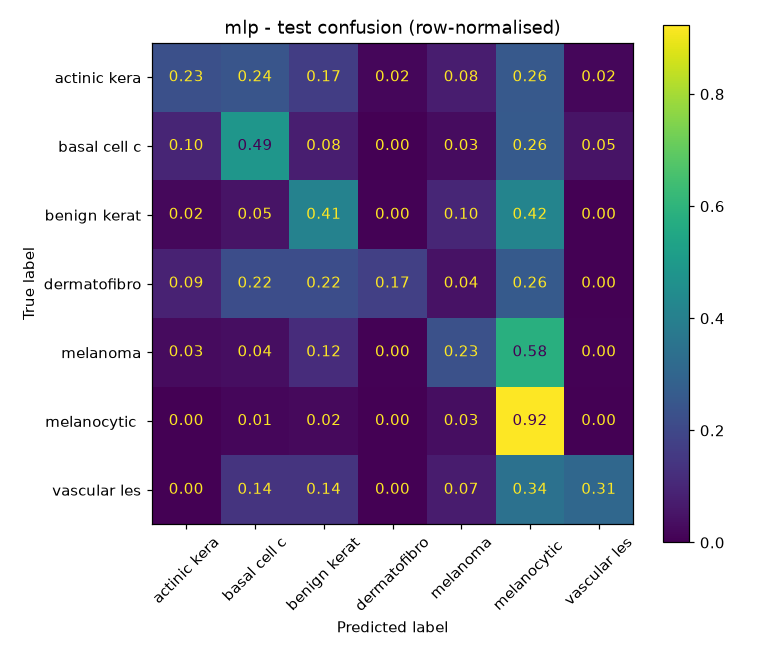

```python
from IPython.display import Image as Img, display
display(Img('results/model_comparison.png'))
display(Img(f'results/confusion_{res.iloc[0].model}.png'))
```

### Calibration: reliability diagram for the registered model

```python
import json, mlflow.sklearn
mlflow.set_tracking_uri(cfg['mlflow_uri'])
info = json.load(open('results/best_model.json'))
model = mlflow.sklearn.load_model(info['uri'])
proba = model.predict_proba(X['test']); conf, pred = proba.max(1), proba.argmax(1)
edges = np.linspace(0, 1, 11); mids, accs = [], []
for lo, hi in zip(edges[:-1], edges[1:]):
    m = (conf > lo) & (conf <= hi)
    if m.sum() > 10:
        mids.append(conf[m].mean()); accs.append((pred[m] == y['test'][m]).mean())
plt.figure(figsize=(4.5, 4.5)); plt.plot([0, 1], [0, 1], 'k--', label='perfect')
plt.plot(mids, accs, 'o-', label=info['model']); plt.xlabel('confidence'); plt.ylabel('accuracy')
plt.title(f"Reliability (test ECE raw={train.ece(y['test'], proba):.3f}, temp-scaled={train.ece(y['test'], train.apply_temperature(proba, info['temperature'])):.3f})", fontsize=9); plt.legend(); plt.show()
```

[output not shown]

```python
from sklearn.metrics import classification_report
print(classification_report(y['test'], pred, target_names=CLASSES, digits=3))
```

```
                               precision    recall  f1-score   support

            actinic keratoses      0.385     0.227     0.286        66
         basal cell carcinoma      0.439     0.485     0.461       103
benign keratosis-like lesions      0.514     0.409     0.456       220
               dermatofibroma      0.444     0.174     0.250        23
                     melanoma      0.395     0.229     0.290       223
             melanocytic nevi      0.815     0.924     0.866      1341
             vascular lesions      0.500     0.310     0.383        29

                     accuracy                          0.727      2005
                    macro avg      0.499     0.394     0.427      2005
                 weighted avg      0.693     0.727     0.703      2005
```

## 7. Inspect MLflow runs and the model registry

UI: `mlflow ui --backend-store-uri sqlite:///mlflow.db --port 5000`, then open http://127.0.0.1:5000

```python
runs = mlflow.search_runs(experiment_names=[cfg['experiment']])
runs[['tags.mlflow.runName', 'metrics.val_macro_f1', 'metrics.test_macro_f1', 'metrics.test_ece']].sort_values('metrics.val_macro_f1', ascending=False).head(5)
```

|  | tags.mlflow.runName | metrics.val_macro_f1 | metrics.test_macro_f1 | metrics.test_ece |
| --- | --- | --- | --- | --- |
| 0 | mlp | 0.474691 | 0.427260 | 0.124443 |
| 1 | hist_gb | 0.406143 | 0.418984 | 0.042338 |
| 3 | logreg | 0.342681 | 0.362908 | 0.093310 |
| 2 | random_forest | 0.247950 | 0.259182 | 0.035026 |
| 4 | dummy_prior | 0.114525 | 0.114508 | 0.000931 |

```python
client = mlflow.MlflowClient()
[(v.name, v.version, v.run_id) for v in client.search_model_versions(f"name='{cfg['registered_model']}'")]
```

```
[('dermamnist-classifier', 1, 'd1ba34fa612641bb8c470177d84fe157')]
```

## 8. FastAPI usage

Start the server with `uvicorn src.api:app --port 8000`. Swagger docs are at http://127.0.0.1:8000/docs. Here we call the same app in-process with `TestClient`. Against a live server, use `requests.post('http://127.0.0.1:8000/predict', json=...)`.

```python
from fastapi.testclient import TestClient
from src.api import app
with TestClient(app) as client:
    print(client.get('/health').json())
    r = client.post('/predict', json={'pixels': splits['test'][0][0].tolist()})
    print(r.status_code, r.json()['label'], '| true:', CLASSES[y['test'][0]])
    bad = client.post('/predict', json={'pixels': [[[1, 2, 3]]]})
    print('bad input ->', bad.status_code, bad.json()['detail'])
```

```
{'status': 'ok', 'model_loaded': True, 'model': {'model': 'mlp', 'run_id': 'd1ba34fa612641bb8c470177d84fe157', 'version': 1, 'temperature': 1.8006, 'uri': 'models:/dermamnist-classifier/1'}, 'error': None}
200 melanocytic nevi | true: melanocytic nevi
bad input -> 422 expected shape (28, 28, 3), got (1, 1, 3)
```

## 9. Conclusions

- **Accuracy is misleading here.** The dummy prior classifier reaches ~67% accuracy with macro-F1 ≈ 0.11. All comparisons therefore lead with macro-F1 and balanced accuracy.
- **Best model** is picked on validation macro-F1 (the MLP). Its test macro-F1 is 0.427 [95% CI 0.374–0.470], statistically tied with HistGB (0.419 [0.379–0.457]). The MLP is significantly more *accurate* (McNemar p<0.0001), but HistGB has better balanced accuracy. Minority classes (dermatofibroma, vascular, actinic keratoses) stay weak for every model.
- **Calibration:** the MLP is over-confident (raw ECE 0.124). A temperature fitted on validation (T≈1.8) cuts test ECE to 0.023, and the API serves these scaled probabilities.
- **Trade-offs:** logistic regression has the best balanced accuracy (class weighting), and random forest has a high AUC but collapses on minority classes, so neither accuracy nor AUC alone is a safe headline.
- **Limitations:** 28×28 resolution, no lesion-level split (HAM10000 has several images per lesion, so leakage is possible), a single seed, no metadata or skin-tone labels, and no CNN.
- **Next:** a CNN/transfer-learning backbone at 224 px, a lesion-grouped split, multi-seed runs, and metadata fusion on PAD-UFES-20/SCIN (see `docs/final_report.md`).